# Home Work Assignment - 04

Critical Thinking Group 5

# 1 Overview

The data set contains approximately 8161 records. Each record represents a customer profile at an auto insurance company. Each record has two response variables.  
The first response variable, TARGET_FLAG, is a 1 or a 0. A “1” means that the person was in a car crash. A zero means that the person was not in a car crash.  
The second response variable is TARGET_AMT. This is the amount spent on repairs if there was a crash. This value is zero if the person did not crash their car. But if they did crash their car, this number will be a value greater than zero.  
We will be exploring, analyzing, and modeling the training data. Since there are 2 different predictions we have to work with, we will deal with each prediction independently. The following are the 2 predictions we will be modeling for:  
1. TARGET_FLAG - This dependent variable tells whether there was a crash or not. This is a binary variable and as such we will be using a Logistic Regression Model to predict this.  
2. TARGET_AMT - This dependent variable gives the amount / cost of repairs if there was a crash. This is a continuous variable and we will ve using a Linear Regression Model to predict this.  
Each of the above models will be built and evaluated separately. In the first section of this document we will deal with the Logistic Model for TARGET_FLAG and in the second section we will deal with Linear Model for the TARGET_AMT  
Out of the many models for each task, we will go ahead and shortlist one model that works the best. We will then use these models (one for each task) on the test / evaluation data.  
To attain our objective, we will be follow the below steps for each modeling exercise:  
1 -Data Exploration  
2 -Data Preparation  
3 -Build Models  
4 -Select Models  
**Model Selection Strategy:** As a strategy, we will split the train dataset into 2 parts - TRAIN and VALID. In the VALID dataset, we will hold out some values to validate how well the model is trained using the TRAIN dataset. We will then use the Model that performs the best on the EVALUATION data to give the required output. We will split the TRAIN / VALID data after the **Data Exploration / Preparation** before the **Build Models**.  
**Please Note:**  
- While working on the Linear Models for the TARGET_AMT, we will be using only a subset of the data where the TARGET_FLAG = 1. This will give us all the records where there was a crash and subsequently a repair amount.  
- While Predicting the TARGET_AMT with the given Evaluation dataset, We will do 2 evaluations:  
1. Independent Prediction - Here we use the Evaluation dataset variables to predict the TARGET_AMT without the need to predict the TARGET_FLAG since the model has been developed independently.  
2. Dependent Prediction - Here we will take the output of the TARGET_FLAG predictions on the Evaluation dataset and use only those rows that were classified as a “Crash” and use it as the input to the TARGET_AMT prediction. So this is a two step prediction, one for the TARGET_FLAG and using the output to predict TARGET_AMT.

# 2 Logistic Regression for TARGET_FLAG

In this section we will use Logistic regression to model the TARGET_FLAG. We will first start with the Data Exploration.

## 2.1 Data Exploration Analysis

In this sub-section we will explore and gain some insights into the dataset by pursuing the below high level steps and inquiries:  
-Variable Identification / Relationships  
-Data Summary Analysis  
-Missing Values  
-Outliers identification -Analysis the link function

### 2.1.1 Variable Identification

First let’s display and examine the data dictionary or the data columns as shown in table 1

Variable Description

[output not shown]

```
## 'data.frame':    8161 obs. of  26 variables:
##  $ INDEX      : int  1 2 4 5 6 7 8 11 12 13 ...
##  $ TARGET_FLAG: int  0 0 0 0 0 1 0 1 1 0 ...
##  $ TARGET_AMT : num  0 0 0 0 0 ...
##  $ KIDSDRIV   : int  0 0 0 0 0 0 0 1 0 0 ...
##  $ AGE        : int  60 43 35 51 50 34 54 37 34 50 ...
##  $ HOMEKIDS   : int  0 0 1 0 0 1 0 2 0 0 ...
##  $ YOJ        : int  11 11 10 14 NA 12 NA NA 10 7 ...
##  $ INCOME     : Factor w/ 6613 levels "","$0","$1,007",..: 5033 6292 1250 1 509 746 1488 315 4765 282 ...
##  $ PARENT1    : Factor w/ 2 levels "No","Yes": 1 1 1 1 1 2 1 1 1 1 ...
##  $ HOME_VAL   : Factor w/ 5107 levels "","$0","$100,093",..: 2 3259 348 3917 3034 2 1 4167 2 2 ...
##  $ MSTATUS    : Factor w/ 2 levels "Yes","z_No": 2 2 1 1 1 2 1 1 2 2 ...
##  $ SEX        : Factor w/ 2 levels "M","z_F": 1 1 2 1 2 2 2 1 2 1 ...
##  $ EDUCATION  : Factor w/ 5 levels "<High School",..: 4 5 5 1 4 2 1 2 2 2 ...
##  $ JOB        : Factor w/ 9 levels "","Clerical",..: 7 9 2 9 3 9 9 9 2 7 ...
##  $ TRAVTIME   : int  14 22 5 32 36 46 33 44 34 48 ...
##  $ CAR_USE    : Factor w/ 2 levels "Commercial","Private": 2 1 2 2 2 1 2 1 2 1 ...
##  $ BLUEBOOK   : Factor w/ 2789 levels "$1,500","$1,520",..: 434 503 2212 553 802 746 2672 701 135 852 ...
##  $ TIF        : int  11 1 4 7 1 1 1 1 1 7 ...
##  $ CAR_TYPE   : Factor w/ 6 levels "Minivan","Panel Truck",..: 1 1 6 1 6 4 6 5 6 5 ...
##  $ RED_CAR    : Factor w/ 2 levels "no","yes": 2 2 1 2 1 1 1 2 1 1 ...
##  $ OLDCLAIM   : Factor w/ 2857 levels "$0","$1,000",..: 1449 1 1311 1 432 1 1 510 1 1 ...
##  $ CLM_FREQ   : int  2 0 2 0 2 0 0 1 0 0 ...
##  $ REVOKED    : Factor w/ 2 levels "No","Yes": 1 1 1 1 2 1 1 2 1 1 ...
##  $ MVR_PTS    : int  3 0 3 0 3 0 0 10 0 1 ...
##  $ CAR_AGE    : int  18 1 10 6 17 7 1 7 1 17 ...
##  $ URBANICITY : Factor w/ 2 levels "Highly Urban/ Urban",..: 1 1 1 1 1 1 1 1 1 2 ...
```

```
## [1] "Yes"  "z_No"
```

```
## [1] "M"   "z_F"
```

```
## [1] "<High School"  "Bachelors"     "Masters"       "PhD"
## [5] "z_High School"
```

```
## [1] ""              "Clerical"      "Doctor"        "Home Maker"
## [5] "Lawyer"        "Manager"       "Professional"  "Student"
## [9] "z_Blue Collar"
```

```
## [1] "Minivan"     "Panel Truck" "Pickup"      "Sports Car"  "Van"
## [6] "z_SUV"
```

```
## [1] "Highly Urban/ Urban"   "z_Highly Rural/ Rural"
```

```
## [1] "No"  "Yes"
```

```
##      INDEX        TARGET_FLAG       TARGET_AMT        KIDSDRIV
##  Min.   :    1   Min.   :0.0000   Min.   :     0   Min.   :0.0000
##  1st Qu.: 2559   1st Qu.:0.0000   1st Qu.:     0   1st Qu.:0.0000
##  Median : 5133   Median :0.0000   Median :     0   Median :0.0000
##  Mean   : 5152   Mean   :0.2638   Mean   :  1504   Mean   :0.1711
##  3rd Qu.: 7745   3rd Qu.:1.0000   3rd Qu.:  1036   3rd Qu.:0.0000
##  Max.   :10302   Max.   :1.0000   Max.   :107586   Max.   :4.0000
##
##       AGE           HOMEKIDS           YOJ            INCOME
##  Min.   :16.00   Min.   :0.0000   Min.   : 0.0   $0      : 615
##  1st Qu.:39.00   1st Qu.:0.0000   1st Qu.: 9.0           : 445
##  Median :45.00   Median :0.0000   Median :11.0   $26,840 :   4
##  Mean   :44.79   Mean   :0.7212   Mean   :10.5   $48,509 :   4
##  3rd Qu.:51.00   3rd Qu.:1.0000   3rd Qu.:13.0   $61,790 :   4
##  Max.   :81.00   Max.   :5.0000   Max.   :23.0   $107,375:   3
##  NA's   :6                        NA's   :454    (Other) :7086
##  PARENT1        HOME_VAL    MSTATUS      SEX               EDUCATION
##  No :7084   $0      :2294   Yes :4894   M  :3786   <High School :1203
##  Yes:1077           : 464   z_No:3267   z_F:4375   Bachelors    :2242
##             $111,129:   3                          Masters      :1658
##             $115,249:   3                          PhD          : 728
##             $123,109:   3                          z_High School:2330
##             $153,061:   3
##             (Other) :5391
##             JOB          TRAVTIME            CAR_USE        BLUEBOOK
##  z_Blue Collar:1825   Min.   :  5.00   Commercial:3029   $1,500 : 157
##  Clerical     :1271   1st Qu.: 22.00   Private   :5132   $6,000 :  34
##  Professional :1117   Median : 33.00                     $5,800 :  33
##  Manager      : 988   Mean   : 33.49                     $6,200 :  33
##  Lawyer       : 835   3rd Qu.: 44.00                     $6,400 :  31
##  Student      : 712   Max.   :142.00                     $5,900 :  30
##  (Other)      :1413                                      (Other):7843
##       TIF                CAR_TYPE    RED_CAR       OLDCLAIM
##  Min.   : 1.000   Minivan    :2145   no :5783   $0     :5009
##  1st Qu.: 1.000   Panel Truck: 676   yes:2378   $1,310 :   4
##  Median : 4.000   Pickup     :1389              $1,391 :   4
##  Mean   : 5.351   Sports Car : 907              $4,263 :   4
##  3rd Qu.: 7.000   Van        : 750              $1,105 :   3
##  Max.   :25.000   z_SUV      :2294              $1,332 :   3
##                                                 (Other):3134
##     CLM_FREQ      REVOKED       MVR_PTS          CAR_AGE
##  Min.   :0.0000   No :7161   Min.   : 0.000   Min.   :-3.000
##  1st Qu.:0.0000   Yes:1000   1st Qu.: 0.000   1st Qu.: 1.000
##  Median :0.0000              Median : 1.000   Median : 8.000
##  Mean   :0.7986              Mean   : 1.696   Mean   : 8.328
##  3rd Qu.:2.0000              3rd Qu.: 3.000   3rd Qu.:12.000
##  Max.   :5.0000              Max.   :13.000   Max.   :28.000
##                                               NA's   :510
##                  URBANICITY
##  Highly Urban/ Urban  :6492
##  z_Highly Rural/ Rural:1669
##
##
##
##
##
```

### 2.1.2 Data Summary and Correlation Analysis

In this section, we will create summary data to better understand the relationship each of the variables have with our dependent variables using correlation, central tendency, and dispersion as shown below:

Now we will produce the correlation table between the independent variables and the dependent variable - TARGET_FLAG

Correlation between TARGET_FLAG and predictor variables

|  | Correlation_TARGET_FLAG |
| --- | --- |
| TARGET_FLAG | 1.0000000 |
| URBANICITY_Highly.Urban..Urban | 0.2241940 |
| MVR_PTS | 0.2192671 |
| CLM_FREQ | 0.2159652 |
| PARENT1_Yes | 0.1576594 |
| REVOKED_Yes | 0.1517045 |
| CAR_USE_Commercial | 0.1427163 |
| EDUCATION_High.School | 0.1382094 |
| OLDCLAIM | 0.1378435 |
| MSTATUS_No | 0.1347552 |
| HOMEKIDS | 0.1161499 |
| KIDSDRIV | 0.1040583 |
| JOB_Blue.Collar | 0.1018097 |
| JOB_Student | 0.0770293 |
| CAR_TYPE_Sports.Car | 0.0572627 |
| CAR_TYPE_Pickup | 0.0563353 |
| TRAVTIME | 0.0480461 |
| CAR_TYPE_SUV | 0.0450376 |
| JOB_Clerical | 0.0275791 |
| SEX_F | 0.0206620 |
| JOB_Home.Maker | 0.0112577 |
| RED_CAR_no | 0.0069595 |
| CAR_TYPE_Van | 0.0030163 |
| CAR_TYPE_Panel.Truck | -0.0003471 |
| JOB_Unknown | -0.0031380 |
| RED_CAR_yes | -0.0069595 |
| SEX_M | -0.0206620 |
| JOB_Professional | -0.0391996 |
| EDUCATION_Bachelors | -0.0431408 |
| JOB_Doctor | -0.0580794 |
| JOB_Lawyer | -0.0617528 |
| EDUCATION_PhD | -0.0652170 |
| YOJ | -0.0704997 |
| EDUCATION_Masters | -0.0761613 |
| TIF | -0.0821748 |
| CAR_AGE | -0.1006513 |
| AGE | -0.1033059 |
| BLUEBOOK | -0.1035337 |
| JOB_Manager | -0.1052506 |
| MSTATUS_Yes | -0.1347552 |
| CAR_TYPE_Minivan | -0.1367604 |
| INCOME | -0.1420042 |
| CAR_USE_Private | -0.1427163 |
| REVOKED_No | -0.1517045 |
| PARENT1_No | -0.1576594 |
| HOME_VAL | -0.1838426 |
| URBANICITY_Highly.Rural..Rural | -0.2241940 |

The above table suggests that none of the variables seem to have a very strong correlation with TARGET_FLAG. However, CAR_TYPE_Van, RED_CAR_no, JOB_Home.Maker, SEX_F, JOB_Clerical, CAR_TYPE_SUV, TRAVTIME, CAR_TYPE_Pickup, CAR_TYPE_Sports.Car, JOB_Student, JOB_Blue.Collar, KIDSDRIV, HOMEKIDS, MSTATUS_No, OLDCLAIM, EDUCATION_High.School, CAR_USE_Commercial, REVOKED_Yes, PARENT1_Yes, CLM_FREQ, MVR_PTS, URBANICITY_Highly.Urban..Urban have a positive correlation.  
Similarly, URBANICITY_Highly.Rural..Rural, HOME_VAL, PARENT1_No, REVOKED_No, CAR_USE_Private, INCOME, CAR_TYPE_Minivan, MSTATUS_Yes, JOB_Manager, BLUEBOOK, AGE, CAR_AGE, TIF, EDUCATION_Masters, YOJ, EDUCATION_PhD, JOB_Lawyer, JOB_Doctor, EDUCATION_Bachelors, JOB_Professional, SEX_M, RED_CAR_yes, CAR_TYPE_Panel.Truck have a negative correlation.  
Lets now see how values in some of the variable affects the correlation:  
CAR_TYPE - If you drive Minivans and Panel Trucks you have lesser chance of being in a crash as against Pickups, Sports, SUVs and Vans. Since the distiction is clear, we believe that binning this variable accordingly will help strengthen the correlation.  
EDUCATION - If you have only a high school education then you are more likely to crash than if you have a Bachelors, Masters or a Phd. Again binning this variable will strengthen the correlation.  
JOB - If you are a Student, Homemaker, or in a Blue Collar or Clerical job, you are more likely to be in a crash against Doctor, Lawyer, Manager, professional or Unknown job. Again binning this variable will strengthen the correlation.  
Lets have a look at the following numeric variables that have 0 as one of their values: INCOME, YOJ, HOME_VAL, OLDCLAIM, CLM_FREQ, MVR_PTS, CAR_AGE, AGE, BLUEBOOK, TIF, TRAVTIME. The goal here is to see if we can bin these variables into zero and non-zero bin values and check the correlations. While doing that we will also see how the variables are distributed vis-a-vis TARGET_FLAG.

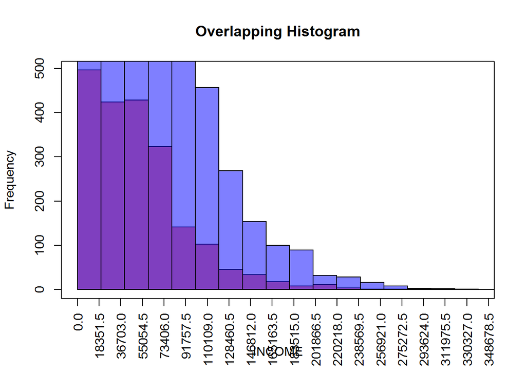

```r
show_hist <- function(var) {

    col_x <- which(colnames(insure_train_full)==var)
    h0 <- select(insure_train_full[insure_train_full$TARGET_FLAG==1,], col_x)
    h1 <- select(insure_train_full[insure_train_full$TARGET_FLAG==0,], col_x)

    min_x <- min(select(insure_train_full, col_x), na.rm = TRUE)
    max_x <- max(select(insure_train_full, col_x), na.rm = TRUE)
    by_x <- (max_x - min_x) / 20


    hist(h0[,1], breaks = 20, col=rgb(1,0,0,0.5), main="Overlapping Histogram", xlab = var, xaxt = "n")
    axis(1, at = seq(min_x, max_x, by = by_x), las=2)

    hist(h1[,1], breaks = 20, col=rgb(0,0,1,0.5), add=T) #
#    axis(1, at = seq(min_x, max_x, by = by_x), las=2)

    box()
}

check_bins <- function(var, thresholds) {

    col_x <- which(colnames(insure_train_full)==var)
    old_x <- select(insure_train_full, col_x)
    cor_old <- cor(old_x, insure_train_full$TARGET_FLAG,use = 'na.or.complete')
    ds <- data.frame("Item" = "Original", "Correlation"= round(cor_old, 5))


    for(i in 1:length(thresholds)) {
        New_x <- ifelse(select(insure_train_full, col_x)<=thresholds[i],0,1)
        cor_new <- cor(New_x, insure_train_full$TARGET_FLAG,use = 'na.or.complete')
        ds_1 <- data.frame("Item" = as.character(thresholds[i]), "Correlation"= round(cor_new, 5))
        ds <- rbind(ds, ds_1)
    }
    return (ds)
}

show_hist("INCOME")
```

```r
check_bins("INCOME", c(0, 20000, 90000, 130000))
```

```
##             Item Correlation
## INCOME  Original    -0.14200
## INCOME1        0    -0.09456
## INCOME2    20000    -0.09371
## INCOME3    90000    -0.12630
## INCOME4   130000    -0.07651
```

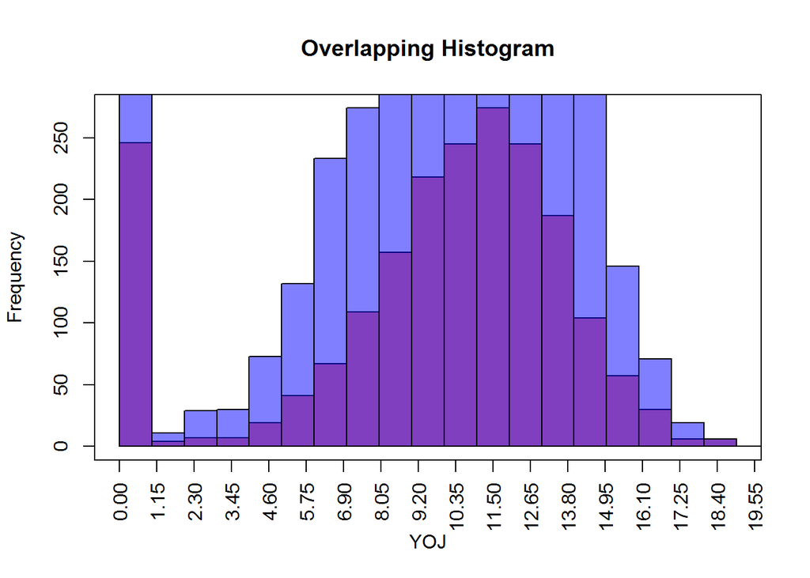

```r
show_hist("YOJ")
```

```r
check_bins("YOJ", c(0, 4, 8, 15))
```

```
##          Item Correlation
## YOJ  Original    -0.07050
## YOJ1        0    -0.08783
## YOJ2        4    -0.07559
## YOJ3        8    -0.04359
## YOJ4       15     0.01236
```

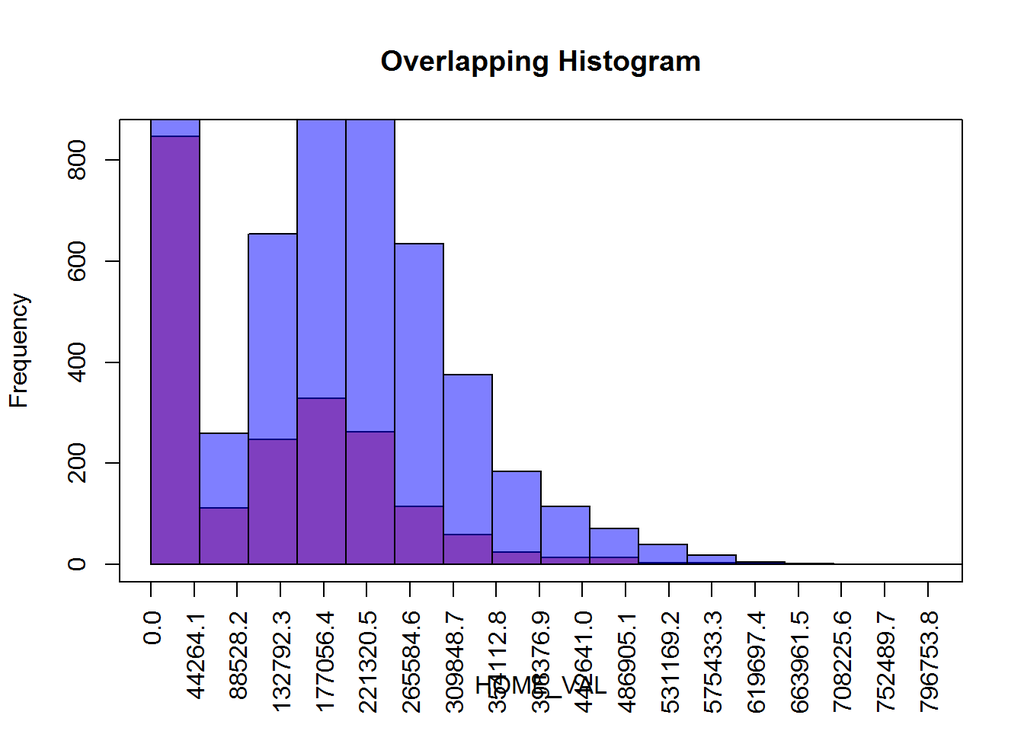

```r
show_hist("HOME_VAL")
```

```r
check_bins("HOME_VAL", c(0, 20000, 90000, 130000))
```

```
##               Item Correlation
## HOME_VAL  Original    -0.18384
## HOME_VAL1        0    -0.15495
## HOME_VAL2    20000    -0.15495
## HOME_VAL3    90000    -0.15776
## HOME_VAL4   130000    -0.15714
```

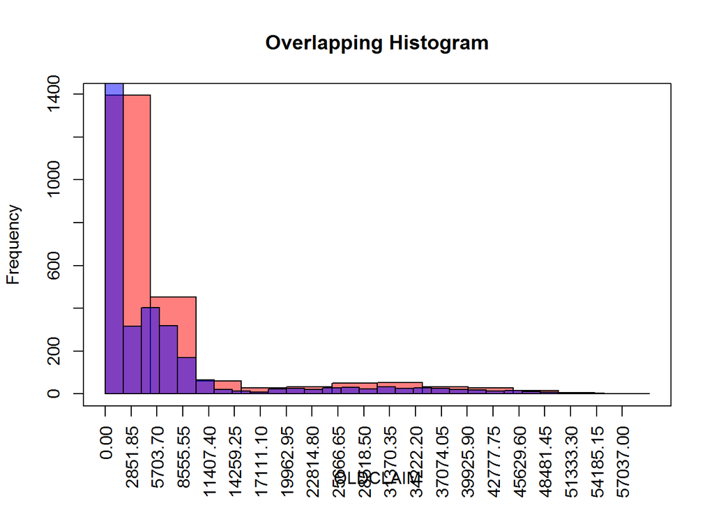

```r
show_hist("OLDCLAIM")
```

```r
check_bins("OLDCLAIM", c(0, 5000, 10000, 15000, 20000, 40000))
```

```
##               Item Correlation
## OLDCLAIM  Original     0.13784
## OLDCLAIM1        0     0.24183
## OLDCLAIM2     5000     0.16565
## OLDCLAIM3    10000     0.09750
## OLDCLAIM4    15000     0.08610
## OLDCLAIM5    20000     0.07898
## OLDCLAIM6    40000     0.03475
```

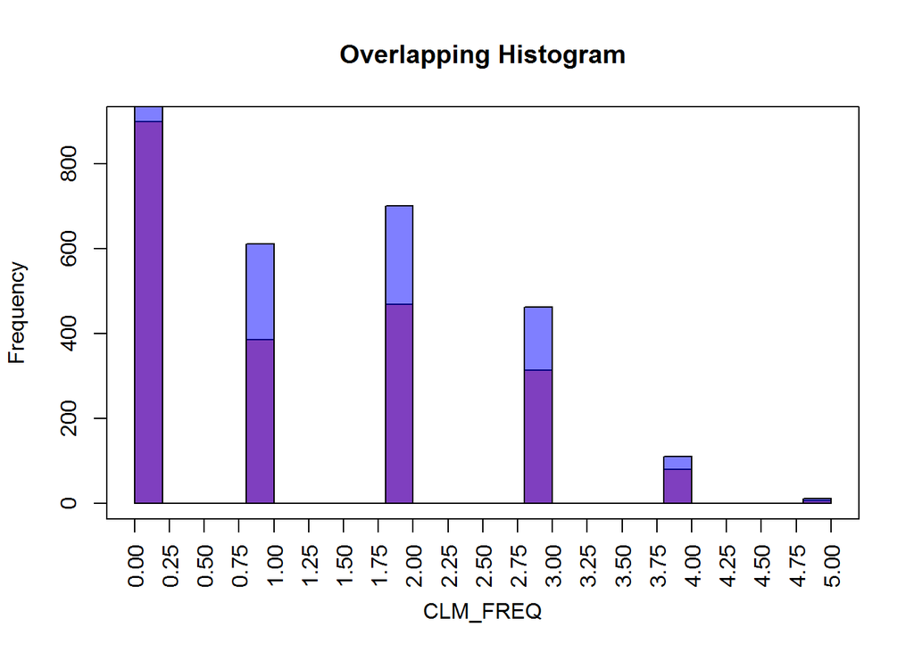

```r
show_hist("CLM_FREQ")
```

```r
check_bins("CLM_FREQ", c(0, 1, 2, 3, 4))
```

```
##               Item Correlation
## CLM_FREQ  Original     0.21597
## CLM_FREQ1        0     0.24183
## CLM_FREQ2        1     0.18996
## CLM_FREQ3        2     0.12019
## CLM_FREQ4        3     0.05669
## CLM_FREQ5        4     0.01335
```

```r
table(insure_train_full$MVR_PTS)
```

```
##
##    0    1    2    3    4    5    6    7    8    9   10   11   13
## 3710 1156  948  757  599  399  266  167   84   45   13   11    2
```

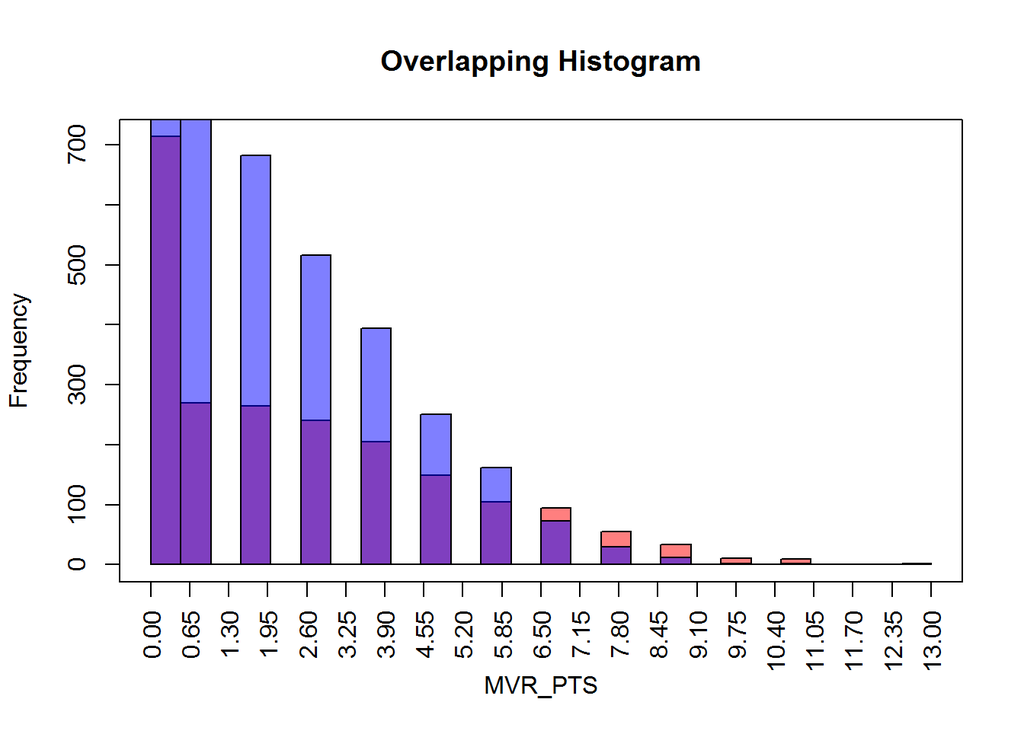

```r
show_hist("MVR_PTS")
```

```r
check_bins("MVR_PTS", c(0:12))
```

```
##               Item Correlation
## MVR_PTS   Original     0.21927
## MVR_PTS1         0     0.14792
## MVR_PTS2         1     0.16997
## MVR_PTS3         2     0.17513
## MVR_PTS4         3     0.17121
## MVR_PTS5         4     0.16770
## MVR_PTS6         5     0.16443
## MVR_PTS7         6     0.17007
## MVR_PTS8         7     0.14080
## MVR_PTS9         8     0.10861
## MVR_PTS10        9     0.07472
## MVR_PTS11       10     0.05279
## MVR_PTS12       11     0.02616
## MVR_PTS13       12     0.02616
```

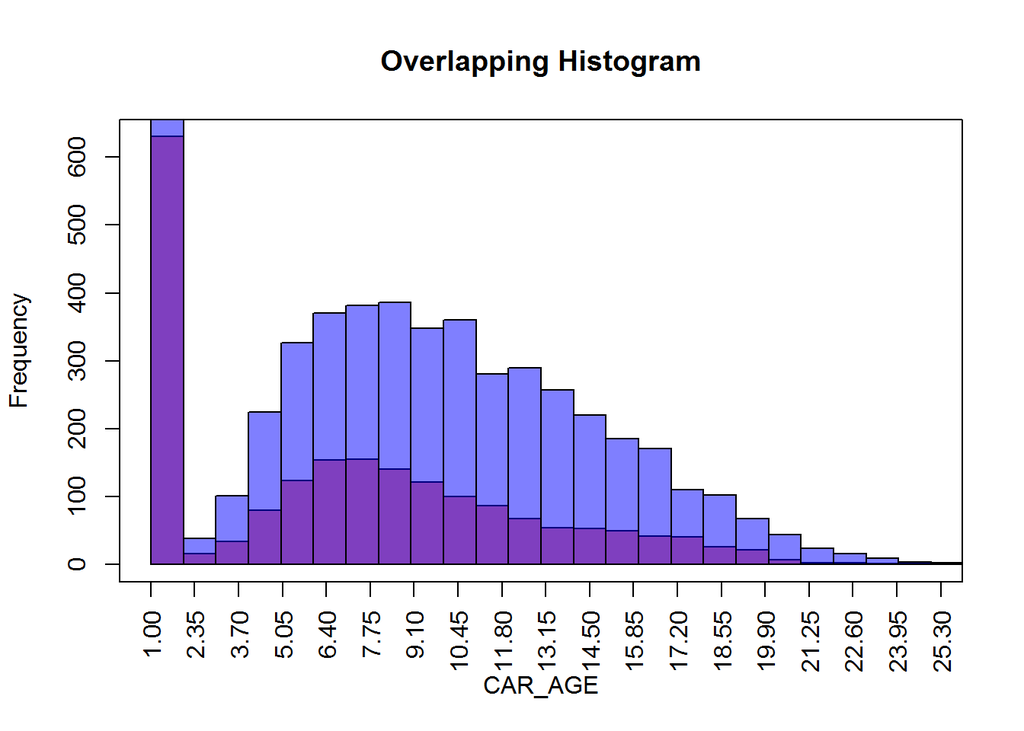

```r
#table(insure_train_full$CAR_AGE)
show_hist("CAR_AGE")
```

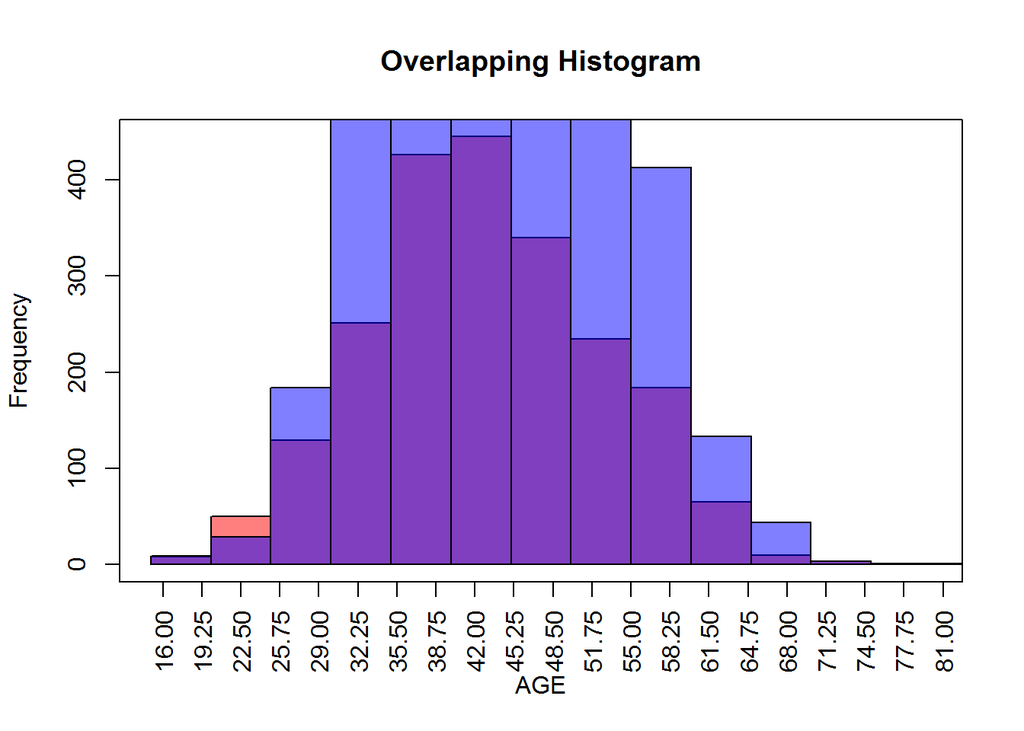

```r
#check_bins("CAR_AGE", c(1:27))

#table(insure_train_full$AGE)
show_hist("AGE")
```

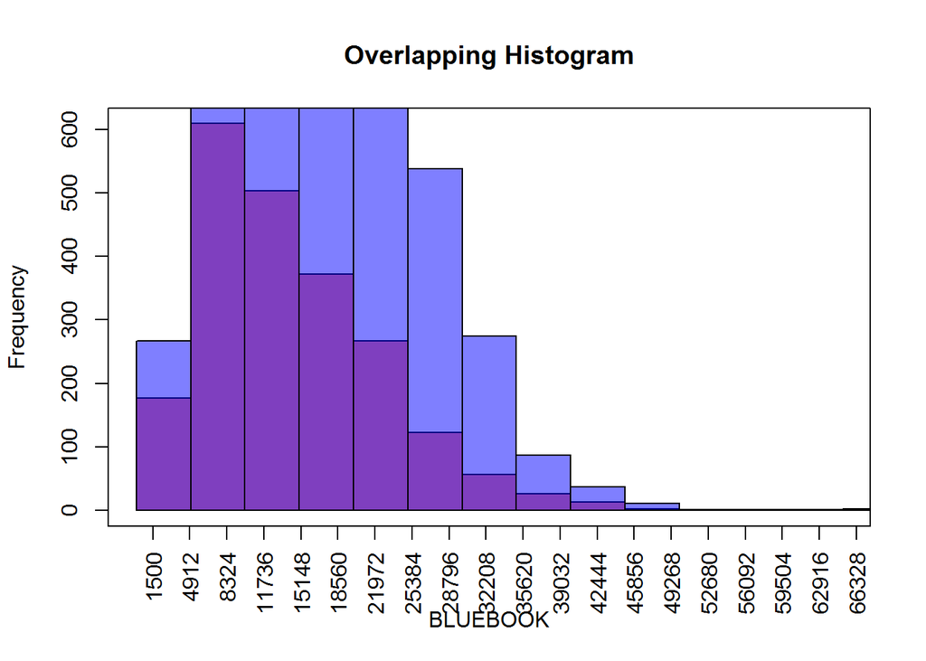

```r
#check_bins("AGE", c(16:80))

#table(insure_train_full$BLUEBOOK)
show_hist("BLUEBOOK")
```

```r
#check_bins("BLUEBOOK", c(11000, 41000, 41050, 57500, 58000))

table(insure_train_full$TIF)
```

```
##
##    1    2    3    4    5    6    7    8    9   10   11   12   13   14   15
## 2532    6  424 1241   52 1341  620   60  225  779  242   45  278   78   31
##   16   17   18   19   20   21   22   25
##   43  104   24    8    8   11    3    2
```

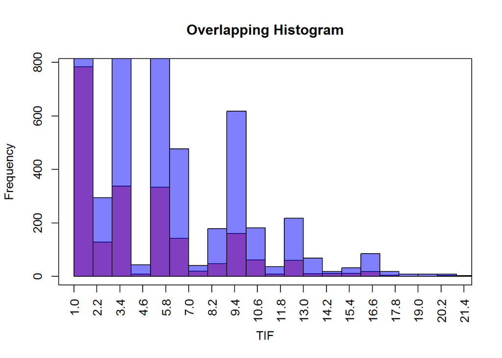

```r
show_hist("TIF")
```

```r
check_bins("TIF", c(1, 4, 6, 10, 24))
```

```
##          Item Correlation
## TIF  Original    -0.08217
## TIF1        1    -0.06734
## TIF2        4    -0.07801
## TIF3        6    -0.06872
## TIF4       10    -0.03715
## TIF5       24    -0.00937
```

```r
table(insure_train_full$TRAVTIME)
```

```
##
##   5   6   7   8   9  10  11  12  13  14  15  16  17  18  19  20  21  22
## 334  49  43  54  70  87  70  97  97 102  92 117 117 121 135 131 169 164
##  23  24  25  26  27  28  29  30  31  32  33  34  35  36  37  38  39  40
## 157 204 212 181 173 188 207 219 190 214 206 201 219 211 202 186 175 196
##  41  42  43  44  45  46  47  48  49  50  51  52  53  54  55  56  57  58
## 175 154 153 162 167 145 125 128 125 106 102 110  82  62  72  73  71  56
##  59  60  61  62  63  64  65  66  67  68  69  70  71  72  73  74  75  76
##  50  44  46  37  25  37  26  30  19  20  21  18  15   8   8  10  10   4
##  77  78  79  80  81  82  83  84  85  86  87  88  90  91  92  93  95  97
##   8   8   5   7   5   4   3   3   2   2   4   3   3   1   1   1   2   2
##  98 101 103 113 124 134 142
##   1   1   1   1   1   1   1
```

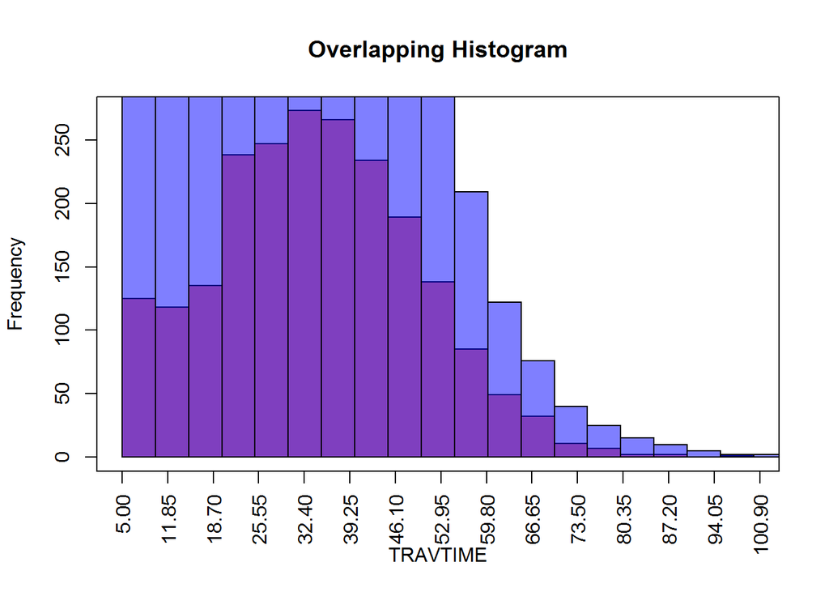

```r
show_hist("TRAVTIME")
```

```r
check_bins("TRAVTIME", c(21, 59, 120))
```

```
##               Item Correlation
## TRAVTIME  Original     0.04805
## TRAVTIME1       21     0.05432
## TRAVTIME2       59     0.00188
## TRAVTIME3      120    -0.01148
```

From the outputs above, we can come to the following conclusions:

-BLUEBOOK - There is no specific pattern that emerges. We will retain the variable as is.

- TIF - Looking at the plots, values and the correlations with TARGET_FLAG, we can conclude that this is not a good variable for binning. We will retain this variable as is.
- TRAVTIME - from the plot, we can see that there is a clear pattern around the value - 20. We will go ahead and create a binned variable for this.

We will carry out the above transformations in the Data Preparation phase.

### 2.1.3 Missing Values

Based on the missing data from the below table, we can see that there are a few missing values for AGE, YOJ, INCOME, HOME_VAL, CAR_AGE variables.  
Table: Missing Values

|  | missings |
| --- | --- |
| TARGET_FLAG | 0 |
| TARGET_AMT | 0 |
| KIDSDRIV | 0 |
| AGE | 6 |
| HOMEKIDS | 0 |
| YOJ | 454 |
| INCOME | 445 |
| PARENT1 | 0 |
| HOME_VAL | 464 |
| MSTATUS | 0 |
| SEX | 0 |
| EDUCATION | 0 |
| JOB | 0 |
| TRAVTIME | 0 |
| CAR_USE | 0 |
| BLUEBOOK | 0 |
| TIF | 0 |
| CAR_TYPE | 0 |
| RED_CAR | 0 |
| OLDCLAIM | 0 |
| CLM_FREQ | 0 |
| REVOKED | 0 |
| MVR_PTS | 0 |
| CAR_AGE | 510 |
| URBANICITY | 0 |
| PARENT1_No | 0 |
| PARENT1_Yes | 0 |
| MSTATUS_No | 0 |
| MSTATUS_Yes | 0 |
| SEX_F | 0 |
| SEX_M | 0 |
| EDUCATION_Bachelors | 0 |
| EDUCATION_High.School | 0 |
| EDUCATION_Masters | 0 |
| EDUCATION_PhD | 0 |
| JOB_Blue.Collar | 0 |
| JOB_Clerical | 0 |
| JOB_Doctor | 0 |
| JOB_Home.Maker | 0 |
| JOB_Lawyer | 0 |
| JOB_Manager | 0 |
| JOB_Professional | 0 |
| JOB_Student | 0 |
| JOB_Unknown | 0 |
| CAR_USE_Commercial | 0 |
| CAR_USE_Private | 0 |
| CAR_TYPE_Minivan | 0 |
| CAR_TYPE_Panel.Truck | 0 |
| CAR_TYPE_Pickup | 0 |
| CAR_TYPE_Sports.Car | 0 |
| CAR_TYPE_SUV | 0 |
| CAR_TYPE_Van | 0 |
| RED_CAR_no | 0 |
| RED_CAR_yes | 0 |
| REVOKED_No | 0 |
| REVOKED_Yes | 0 |
| URBANICITY_Highly.Rural..Rural | 0 |
| URBANICITY_Highly.Urban..Urban | 0 |

We can try and impute values to AGE, YOJ, INCOME, HOME_VAL, CAR_AGE. Lets look at the distributions for each of the variable to determine the value to use to impute.

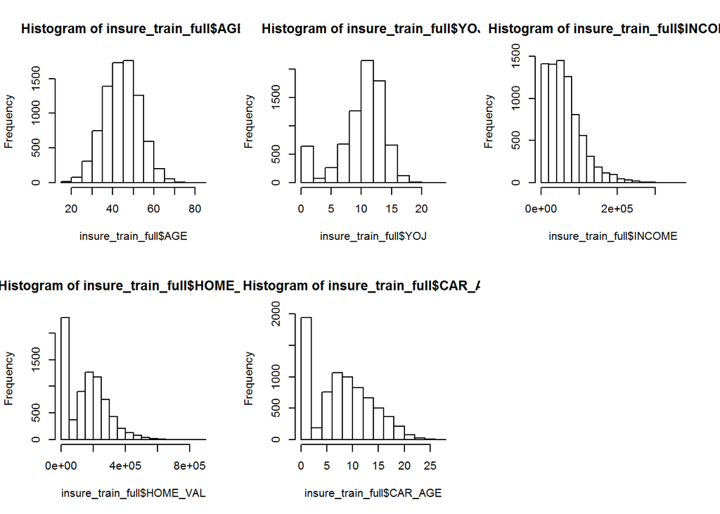

```r
par(mfrow=c(2,3))
hist(insure_train_full$AGE)
hist(insure_train_full$YOJ)
hist(insure_train_full$INCOME)
hist(insure_train_full$HOME_VAL)
hist(insure_train_full$CAR_AGE)
```

Given that Age and YOJ look to be somewhat normally distributed, we can go ahead and use the mean to impute the missing values for these variables. For INCOME, HOME_VAL and CAR_AGE the median seems to be a better value to impute since there are strong right skews. We will carry out these transformation while data preparation.

### 2.1.4 Outliers identification

In this sub-section, we will look at the boxplots and determine the outliers in variables and decide on whether to act on the outliers. We will do the outliers only on some of the currency and few other variables. Below are the plots:

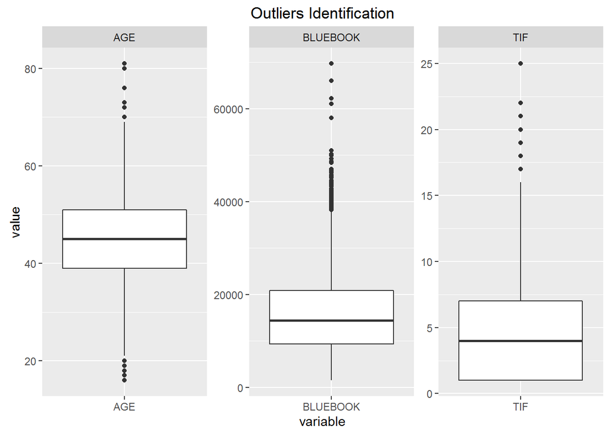

From the “Outliers identification” plot above, we see that we have few outliers that we need to treat. We will treat the outliers in this variable when we do the data preparation for modeling the TARGET_FLAG.

### 2.1.5 Analysis the link function

In this section, we will investigate how our initial data aligns with a typical logistic model plot.

Recall the Logistic Regression is part of a larger class of algorithms known as Generalized Linear Model (glm). The fundamental equation of generalized linear model is:

$g(E(y)) = a+ Bx_1+B_2x_2+ B_3x_3+...$

where, g() is the link function, E(y) is the expectation of target variable and $B_0 + B_1x_1 + B_2x_2+B_3x_3$ is the linear predictor ( $B_0,B_1,B_2, B_3$ to be predicted). The role of link function is to ‘link’ the expectation of y to linear predictor.

In logistic regression, we are only concerned about the probability of outcome dependent variable ( success or failure). As described above, g() is the link function. This function is established using two things: Probability of Success (p) and Probability of Failure (1-p). p should meet following criteria: It must always be positive (since p >= 0) It must always be less than equals to 1 (since p <= 1).

Now let’s investigate how our initial data model aligns with the above criteria. In other words, we will plot regression model plots for each variable and compare it to a typical logistic model plot:

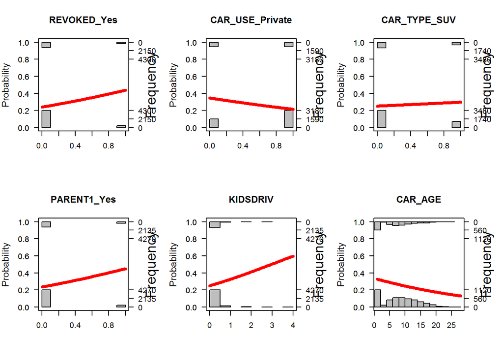

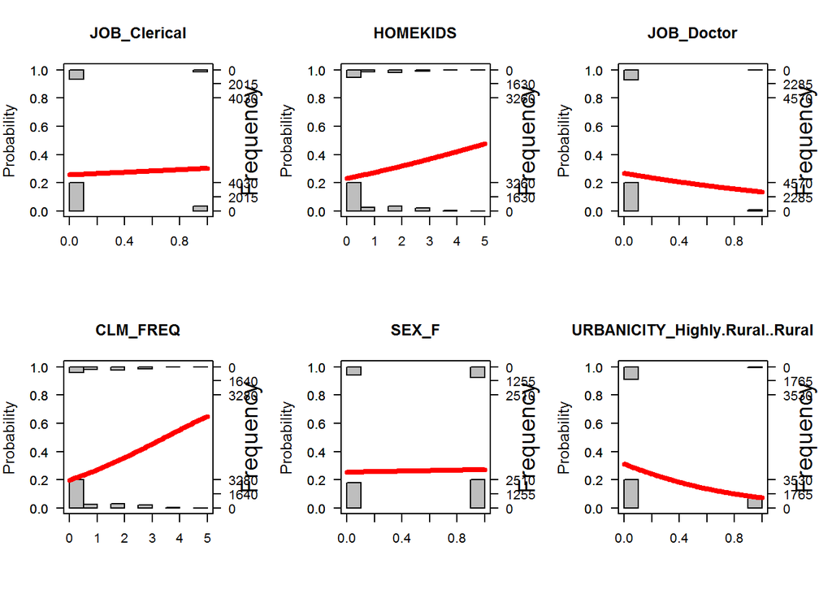

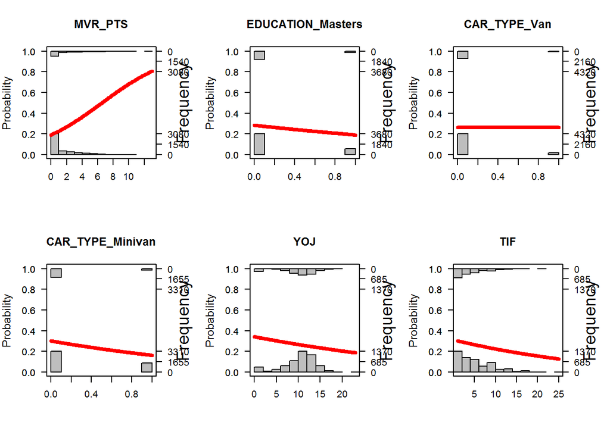

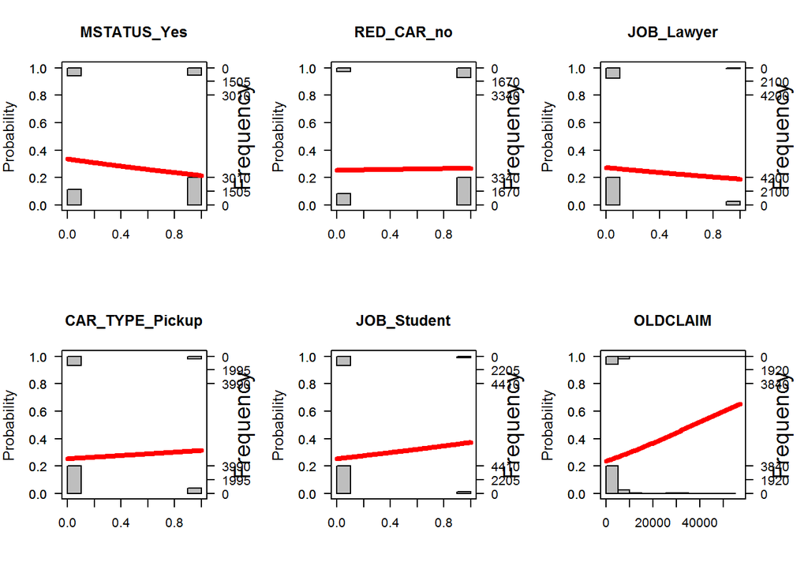

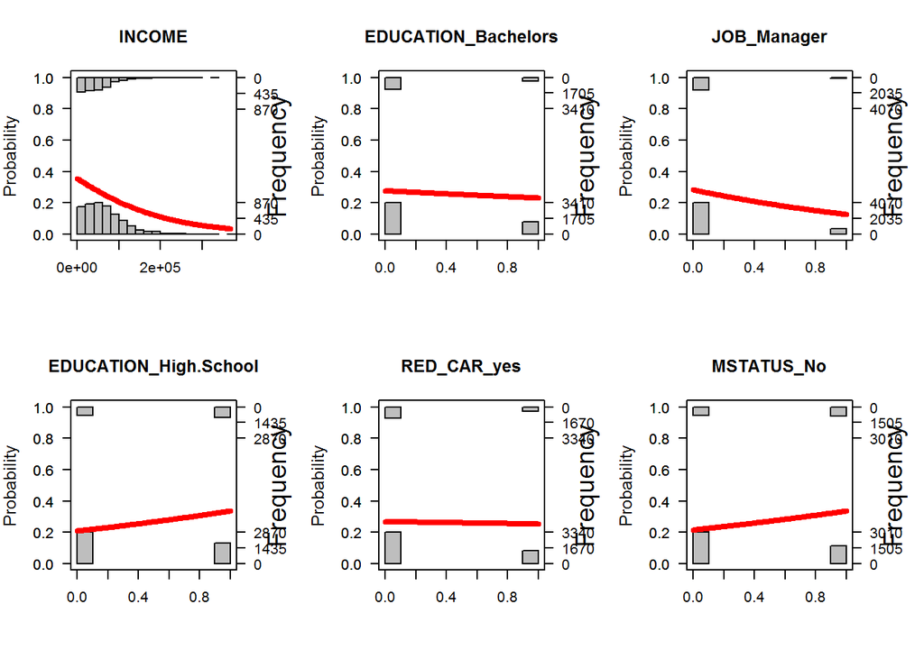

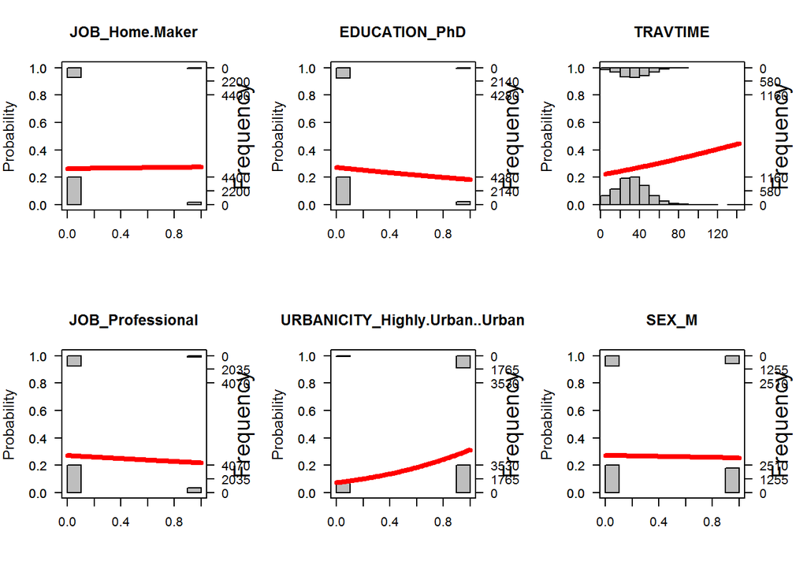

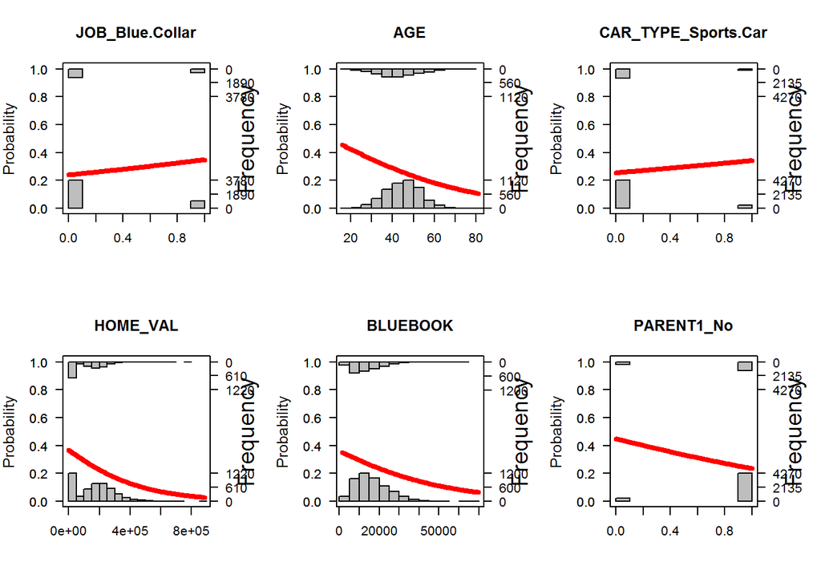

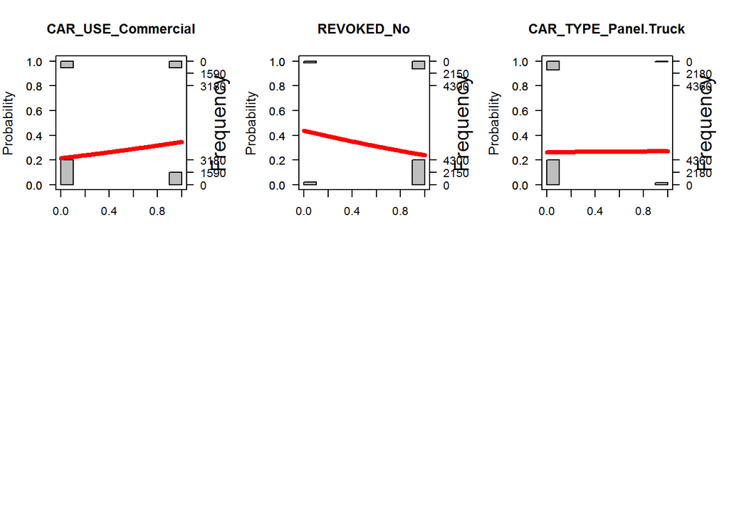

## 2.2 Data Preparation

Now that we have completed the data exploration / analysis, we will be transforming the data for use in analysis and modeling.  
We will be following the below steps as guidelines:  
- Outliers treatment  
- Missing values treatment  
- Adding New Variables

### 2.2.1 Outliers treatment

In this sub-section, we will check different transformations for AGE, BLUEBOOK and TIF to create the appropriate outlier-handled / transformed variables.

**Transformations for TIF**

```
##    Min. 1st Qu.  Median    Mean 3rd Qu.    Max.
##    1.00    1.00    4.00    5.35    7.00   25.00
```

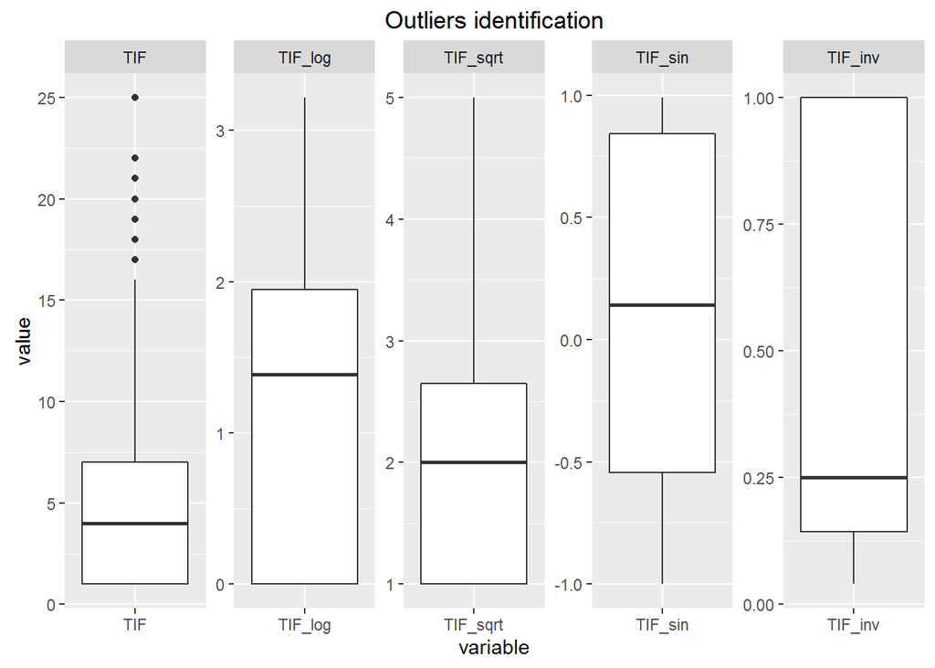

From the above charts we can see that a log, sqrt, sin or an inverse transformation works well for TIF. However, the sin transformation seems to be better distributed. Hence, We will create this variable.  
**Transformations for BLUEBOOK**

```
##    Min. 1st Qu.  Median    Mean 3rd Qu.    Max.
##    1500    9290   14440   15710   20850   69740
```

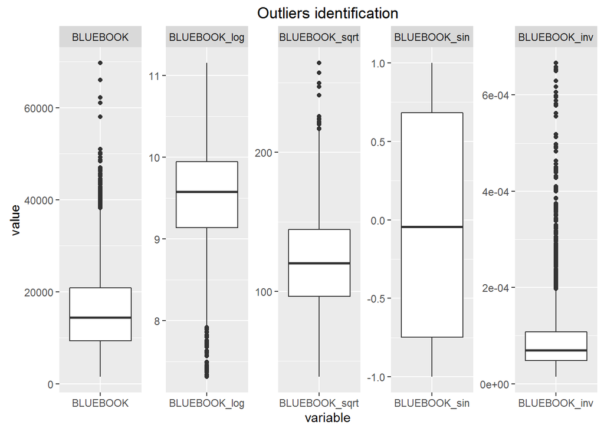

From the above charts we can see that a sin transformation works well. Hence, We will create this variable.  
**Transformations for AGE**

```
##    Min. 1st Qu.  Median    Mean 3rd Qu.    Max.    NA's
##   16.00   39.00   45.00   44.79   51.00   81.00       6
```

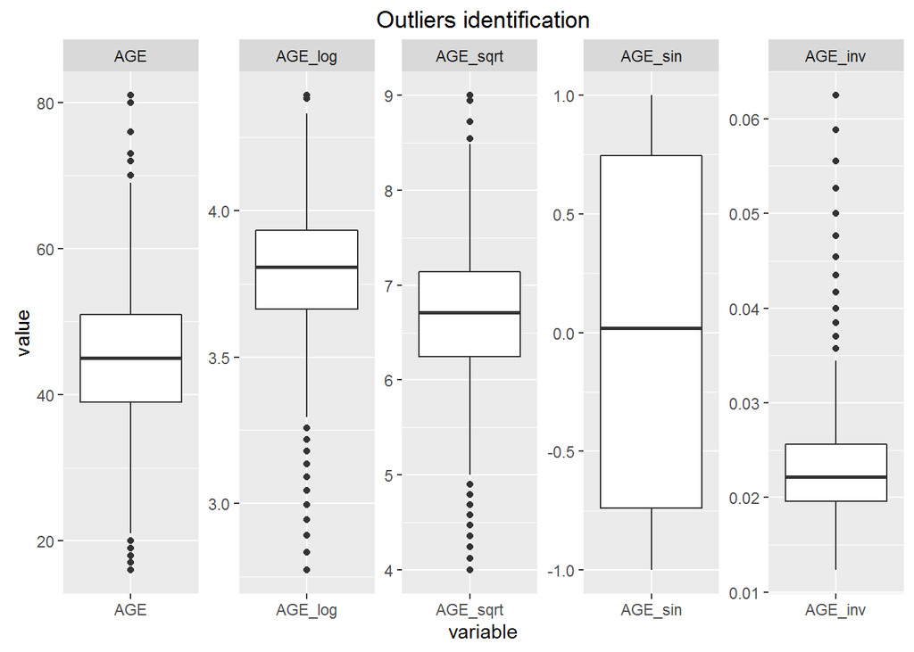

From the above charts we can see that a sin works well for AGE.Hence, We will create this variable.

### 2.2.2 Missing Values treatment

As we have seen in the data exploration phase, Age and YOJ look to be somewhat normally distributed, we can go ahead and use the mean to impute the missing values for these variables. For INCOME, HOME_VAL and CAR_AGE the median seems to be a better value to impute since there are strong right skews.

### 2.2.3 Adding New Variables

In this section, we generate some additional variables that we feel will help the correlations. The following were some of the observations we made during the data exploration phase for TARGET_FLAG  
CAR_TYPE - If you drive Minivans and Panel Trucks you have lesser chance of being in a crash as against Pickups, Sports, SUVs and Vans. Since the distiction is clear, we believe that binning this variable accordingly will help strengthen the correlation. Accordingly, we will bin this variable as below:  
CAR_TYPE_FLAG_BIN :  
- 1 : if CAR_TYPE is Minivans or Panel Trucks  
- 0 : if CAR_TYPE is Pickups, Sports, SUVs or Vans

EDUCATION - If you have only a high school education then you are more likely to crash than if you have a Bachelors, Masters or a Phd. Again binning this variable will strengthen the correlation:  
EDUCATION_FLAG_BIN :  
- 0 : if EDUCATION is High School  
- 1 : if EDUCATION is Bachelors, Masters or Phd  
JOB - If you are a Student, Homemaker, or in a Blue Collar or Clerical job, you are more likely to be in a crash against Doctor, Lawyer, Manager or professional. Again binning this variable will strengthen the correlation:  
JOB_TYPE_FLAG_BIN :  
- 1 : if JOB_TYPE is Student, Homemaker, or in a Blue Collar or Clerical  
- 0 : if JOB_TYPE is Doctor, Lawyer, Manager, professional, Unknown  
- INCOME - Binning this variable seems to make a difference in the correlation. We will go ahead and create a binned variable for this at zero value.  
INCOME_FLAG_BIN :  
- 1 : if INCOME <= 0  
- 0 : if INCOME > 0  
- YOJ - Binning this variable seems to make a difference in the correlation. We will go ahead and create a binned variable for this.  
YOJ_FLAG_BIN :  
- 1 : if YOJ <= 0  
- 0 : if YOJ > 0

- HOME_VAL - Binning this variable seems to make a difference in the correlation. We will go ahead and create a binned variable for this.  
  HOME_VAL_FLAG_BIN :
- 1 : if HOME_VAL <= 0
- 0 : if HOME_VAL > 0

- OLDCLAIM- There is a huge difference in the coorrelation when we transform this vatiable. Binning this variable seems like a good idea.  
OLDCLAIM_FLAG_BIN :  
- 1 : if OLDCLAIM <= 0  
- 0 : if OLDCLAIM > 0  
- CLM_FREQ - Binning this variable seems to make a difference in the correlation. We will go ahead and create a binned variable for this.  
CLM_FREQ_FLAG_BIN :  
- 1 : if CLM_FREQ <= 0  
- 0 : if CLM_FREQ > 0  
- MVR_PTS - Binning this variable seems to make a difference in the correlation. We will go ahead and create a binned variable for this.  
MVR_PTS_FLAG_BIN :  
- 1 : if MVR_PTS <= 0  
- 0 : if MVR_PTS > 0  
- CAR_AGE - There are quite a few records with a 1 year car age. We will use this bound to generate a binned variable as well as retain the original varible as is.  
CAR_AGE_FLAG_BIN :  
- 1 : if CAR_AGE <= 1  
- 0 : if CAR_AGE > 0  
- AGE - There is no specific pattern that emerges. We will retain this variable as is.  
- BLUEBOOK - There is no specific pattern that emerges. We will retain this variable as is.

- TRAVTIME - from the plot, we can see that there is a clear pattern around the value - 20. We will go ahead and create a binned variable for this.  
  TRAVTIME_FLAG_BIN :
- 1 : if TRAVTIME <= 20
- 0 : if TRAVTIME > 0

There are a few variables that are binary and can be converted to 0s and 1s. The following are the variables: CAR_USE_Commercial, CAR_USE_Private, MSTATUS_No, MSTATUS_Yes, PARENT1_No, PARENT1_Yes, RED_CAR_no, RED_CAR_yes, REVOKED_No, REVOKED_Yes, SEX_F, SEX_M, URBANICITY_Highly.Rural..Rural, URBANICITY_Highly.Urban..Urban. We will create a binary variable for each of these as well.

After having prepared the data, we will go ahead and drop some of the variables.

```r
#write.csv(insure_train_full, file = "D:/CUNY/Courses/Business Analytics and Data Mining/Assignments/data621-ctg5/HW4/final.csv")

DS_TARGET_FLAG <- select(insure_train_full, -AGE, -BLUEBOOK, -CAR_TYPE, -CAR_TYPE_Minivan, -CAR_TYPE_Panel.Truck, -CAR_TYPE_Pickup, -CAR_TYPE_Sports.Car, -CAR_TYPE_SUV, -CAR_TYPE_Van, -CAR_USE, -CAR_USE_Private, -CLM_FREQ, -EDUCATION, -EDUCATION_Bachelors, -EDUCATION_High.School, -EDUCATION_Masters, -EDUCATION_PhD, -HOME_VAL, -INCOME, -JOB, -JOB_Blue.Collar, -JOB_Clerical, -JOB_Doctor, -JOB_Home.Maker, -JOB_Lawyer, -JOB_Manager, -JOB_Professional, -JOB_Student, -JOB_Unknown, -MSTATUS, -MSTATUS_No, -MVR_PTS, -OLDCLAIM, -PARENT1, -PARENT1_No, -RED_CAR, -RED_CAR_no, -REVOKED, -REVOKED_No, -SEX, -SEX_F, -TARGET_AMT, -TIF, -TRAVTIME, -URBANICITY, -URBANICITY_Highly.Rural..Rural, -URBANICITY_Highly.Urban..Urban, -YOJ)

str(DS_TARGET_FLAG)
```

```
## 'data.frame':    8157 obs. of  25 variables:
##  $ TARGET_FLAG       : int  0 0 0 0 0 1 0 1 1 0 ...
##  $ KIDSDRIV          : int  0 0 0 0 0 0 0 1 0 0 ...
##  $ HOMEKIDS          : int  0 0 1 0 0 1 0 2 0 0 ...
##  $ CAR_AGE           : int  18 1 10 6 17 7 1 7 1 17 ...
##  $ PARENT1_Yes       : num  0 0 0 0 0 1 0 0 0 0 ...
##  $ MSTATUS_Yes       : num  0 0 1 1 1 0 1 1 0 0 ...
##  $ SEX_M             : num  1 1 0 1 0 0 0 1 0 1 ...
##  $ CAR_USE_Commercial: num  0 1 0 0 0 1 0 1 0 1 ...
##  $ RED_CAR_yes       : num  1 1 0 1 0 0 0 1 0 0 ...
##  $ REVOKED_Yes       : num  0 0 0 0 1 0 0 1 0 0 ...
##  $ TIF_sin           : num  -1 0.841 -0.757 0.657 0.841 ...
##  $ BLUEBOOK_sin      : num  -0.988 -0.988 0.971 0.8 -0.97 ...
##  $ AGE_sin           : num  -0.305 -0.832 -0.428 0.67 -0.262 ...
##  $ CAR_TYPE_FLAG_BIN : num  1 1 0 1 0 0 0 0 0 0 ...
##  $ EDUCATION_FLAG_BIN: num  1 0 0 0 1 1 0 1 1 1 ...
##  $ JOB_TYPE_FLAG_BIN : num  0 1 1 1 0 1 1 1 1 0 ...
##  $ INCOME_FLAG_BIN   : num  0 0 0 0 0 0 0 0 0 0 ...
##  $ YOJ_FLAG_BIN      : num  0 0 0 0 0 0 0 0 0 0 ...
##  $ HOME_VAL_FLAG_BIN : num  1 0 0 0 0 1 0 0 1 1 ...
##  $ OLDCLAIM_FLAG_BIN : num  0 1 0 1 0 1 1 0 1 1 ...
##  $ CLM_FREQ_FLAG_BIN : num  0 1 0 1 0 1 1 0 1 1 ...
##  $ MVR_PTS_FLAG_BIN  : num  0 1 0 1 0 1 1 0 1 0 ...
##  $ CAR_AGE_FLAG_BIN  : num  0 1 0 0 0 0 1 0 1 0 ...
##  $ TRAVTIME_FLAG_BIN : num  1 0 1 0 0 0 0 0 0 0 ...
##  $ URBANICITY_Rural  : num  0 0 0 0 0 0 0 0 0 1 ...
```

## 2.3 Build Models

### 2.3.1 Prepare TRAIN and VALID datasets

However, prior to that, we hold out a subset of data as a validation dataset to check model performance. This will be useful when we select a model.

```r
smp_size <- floor(0.80 * nrow(insure_train_full))

## set the seed to make your partition reproductible
set.seed(123)

train_index <- sample(seq_len(nrow(DS_TARGET_FLAG)), size = smp_size)

DS_TARGET_FLAG_TRAIN<- DS_TARGET_FLAG[train_index, ]
DS_TARGET_FLAG_VALID <- DS_TARGET_FLAG[-train_index, ]
```

### 2.3.2 Model 1

```
##
## Call:
## glm(formula = TARGET_FLAG ~ ., family = "binomial", data = DS_TARGET_FLAG_TRAIN)
##
## Deviance Residuals:
##     Min       1Q   Median       3Q      Max
## -2.1623  -0.7318  -0.4362   0.6965   3.1501
##
## Coefficients: (1 not defined because of singularities)
##                     Estimate Std. Error z value Pr(>|z|)
## (Intercept)        -0.446441   0.167961  -2.658 0.007860 **
## KIDSDRIV            0.385522   0.065303   5.904 3.56e-09 ***
## HOMEKIDS            0.038015   0.036937   1.029 0.303395
## CAR_AGE            -0.003053   0.010350  -0.295 0.768020
## PARENT1_Yes         0.419870   0.119265   3.520 0.000431 ***
## MSTATUS_Yes        -0.471293   0.092723  -5.083 3.72e-07 ***
## SEX_M               0.047181   0.094534   0.499 0.617720
## CAR_USE_Commercial  0.612477   0.070304   8.712  < 2e-16 ***
## RED_CAR_yes        -0.016280   0.095495  -0.170 0.864630
## REVOKED_Yes         0.809090   0.088282   9.165  < 2e-16 ***
## TIF_sin             0.156265   0.047655   3.279 0.001042 **
## BLUEBOOK_sin       -0.032733   0.044816  -0.730 0.465151
## AGE_sin             0.012849   0.045317   0.284 0.776775
## CAR_TYPE_FLAG_BIN  -0.672289   0.076416  -8.798  < 2e-16 ***
## EDUCATION_FLAG_BIN -0.441233   0.093348  -4.727 2.28e-06 ***
## JOB_TYPE_FLAG_BIN   0.517657   0.090970   5.690 1.27e-08 ***
## INCOME_FLAG_BIN     0.664119   0.330232   2.011 0.044318 *
## YOJ_FLAG_BIN       -0.076524   0.329664  -0.232 0.816440
## HOME_VAL_FLAG_BIN   0.234239   0.085181   2.750 0.005961 **
## OLDCLAIM_FLAG_BIN  -0.559409   0.067336  -8.308  < 2e-16 ***
## CLM_FREQ_FLAG_BIN         NA         NA      NA       NA
## MVR_PTS_FLAG_BIN   -0.305347   0.068346  -4.468 7.91e-06 ***
## CAR_AGE_FLAG_BIN    0.001577   0.111594   0.014 0.988723
## TRAVTIME_FLAG_BIN  -0.443202   0.081917  -5.410 6.29e-08 ***
## URBANICITY_Rural   -2.203072   0.122669 -17.959  < 2e-16 ***
## ---
## Signif. codes:  0 '***' 0.001 '**' 0.01 '*' 0.05 '.' 0.1 ' ' 1
##
## (Dispersion parameter for binomial family taken to be 1)
##
##     Null deviance: 7537.8  on 6518  degrees of freedom
## Residual deviance: 6030.7  on 6495  degrees of freedom
##   (6 observations deleted due to missingness)
## AIC: 6078.7
##
## Number of Fisher Scoring iterations: 5
```

### 2.3.3 Model 2

```
##
## Classification tree:
## rpart(formula = TARGET_FLAG ~ ., data = DS_TARGET_FLAG_TRAIN,
##     method = "class")
##
## Variables actually used in tree construction:
## [1] CAR_TYPE_FLAG_BIN  CAR_USE_Commercial JOB_TYPE_FLAG_BIN
## [4] KIDSDRIV           OLDCLAIM_FLAG_BIN  REVOKED_Yes
## [7] URBANICITY_Rural
##
## Root node error: 1732/6525 = 0.26544
##
## n= 6525
##
##         CP nsplit rel error  xerror     xstd
## 1 0.011692      0   1.00000 1.00000 0.020594
## 2 0.010970      6   0.91339 0.95843 0.020312
## 3 0.010000      7   0.90242 0.94919 0.020247
```

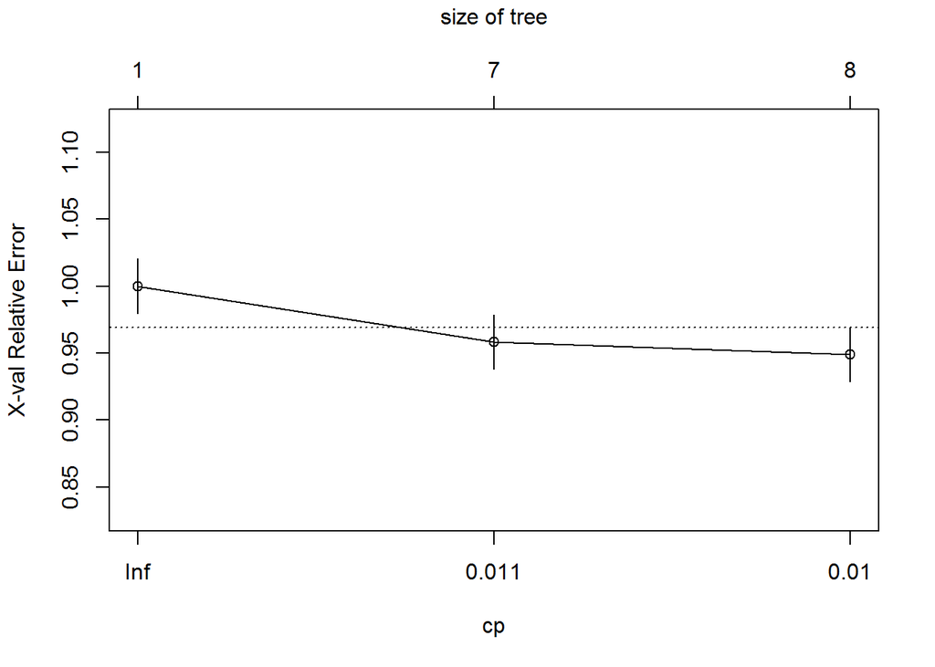

```
## Call:
## rpart(formula = TARGET_FLAG ~ ., data = DS_TARGET_FLAG_TRAIN,
##     method = "class")
##   n= 6525
##
##           CP nsplit rel error    xerror       xstd
## 1 0.01169169      0 1.0000000 1.0000000 0.02059394
## 2 0.01096998      6 0.9133949 0.9584296 0.02031222
## 3 0.01000000      7 0.9024249 0.9491917 0.02024730
##
## Variable importance
##  CLM_FREQ_FLAG_BIN  OLDCLAIM_FLAG_BIN  JOB_TYPE_FLAG_BIN
##                 30                 30                  9
##           KIDSDRIV   URBANICITY_Rural EDUCATION_FLAG_BIN
##                  5                  5                  5
##        REVOKED_Yes            CAR_AGE  CAR_TYPE_FLAG_BIN
##                  4                  4                  3
##   MVR_PTS_FLAG_BIN CAR_USE_Commercial              SEX_M
##                  2                  2                  1
##           HOMEKIDS   CAR_AGE_FLAG_BIN
##                  1                  1
##
## Node number 1: 6525 observations,    complexity param=0.01169169
##   predicted class=0  expected loss=0.2654406  P(node) =1
##     class counts:  4793  1732
##    probabilities: 0.735 0.265
##   left son=2 (4015 obs) right son=3 (2510 obs)
##   Primary splits:
##       OLDCLAIM_FLAG_BIN < 0.5        to the right, improve=142.51400, (0 missing)
##       CLM_FREQ_FLAG_BIN < 0.5        to the right, improve=142.51400, (0 missing)
##       URBANICITY_Rural  < 0.5        to the right, improve=126.85740, (0 missing)
##       REVOKED_Yes       < 0.5        to the left,  improve= 68.26899, (0 missing)
##       PARENT1_Yes       < 0.5        to the left,  improve= 64.02526, (0 missing)
##   Surrogate splits:
##       CLM_FREQ_FLAG_BIN < 0.5        to the right, agree=1.000, adj=1.000, (0 split)
##       MVR_PTS_FLAG_BIN  < 0.5        to the right, agree=0.642, adj=0.070, (0 split)
##       KIDSDRIV          < 2.5        to the left,  agree=0.616, adj=0.001, (0 split)
##
## Node number 2: 4015 observations
##   predicted class=0  expected loss=0.1828144  P(node) =0.6153257
```

[output cut: 115 more lines]

```
##       SEX_M           < 0.5        to the left,  agree=0.656, adj=0.267, (0 split)
##       RED_CAR_yes     < 0.5        to the left,  agree=0.596, adj=0.139, (0 split)
##       CAR_AGE         < 7.5        to the left,  agree=0.556, adj=0.056, (0 split)
##       BLUEBOOK_sin    < -0.5058197 to the right, agree=0.546, adj=0.033, (0 split)
##       INCOME_FLAG_BIN < 0.5        to the right, agree=0.546, adj=0.033, (0 split)
##
## Node number 122: 405 observations
##   predicted class=0  expected loss=0.4493827  P(node) =0.06206897
##     class counts:   223   182
##    probabilities: 0.551 0.449
##
## Node number 123: 359 observations
##   predicted class=1  expected loss=0.4038997  P(node) =0.05501916
##     class counts:   145   214
##    probabilities: 0.404 0.596
```

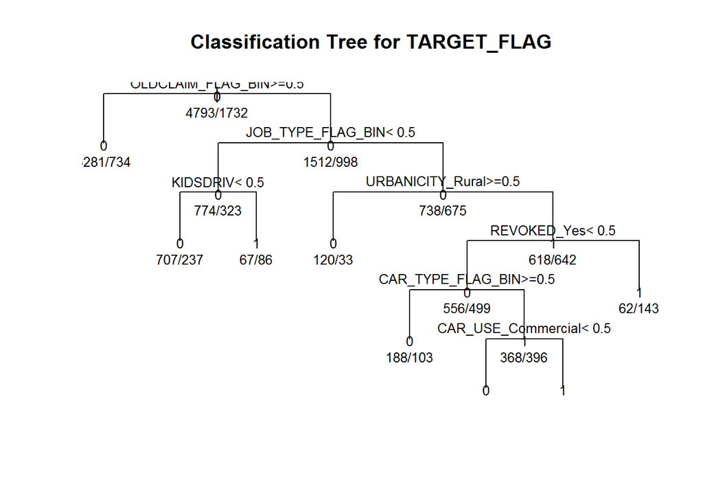

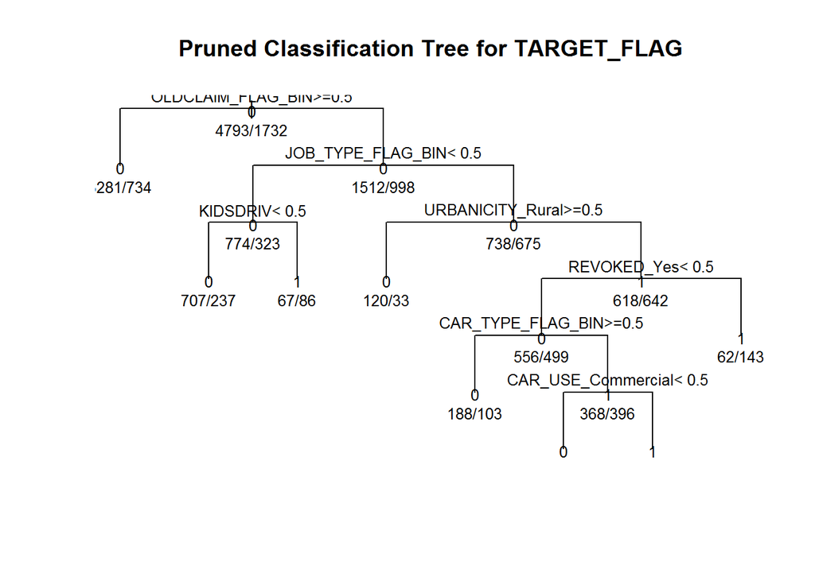

$\newline$

### 2.3.4 Model 3

```
##           Length Class  Mode
## prior      2     -none- numeric
## counts     2     -none- numeric
## means     48     -none- numeric
## scaling   24     -none- numeric
## lev        2     -none- character
## svd        1     -none- numeric
## N          1     -none- numeric
## call       3     -none- call
## terms      3     terms  call
## xlevels    0     -none- list
## na.action  6     omit   numeric
```

$\newline$

# 3 Linear Regression for TARGET_AMT

In this section we will use Linear regression to model the TARGET_AMT. We will first start with the Data Exploration.

## 3.1 Data Exploration Analysis

In this analysis, we will be using only those records where the TARGET_FLAG is 1. This indicates that the vehicle crashed. In such a scenario, we will be modeling the cost of repair using Linear Regression. First, lets create the required data set for the “Crashed” data from the existing “clean” full data and look at the structure of the resulting dataset. We will remove from the new “crashed” dataset all those variables that were created specifically for predicting TARGET_FLAG. We will be creating these variables separately for predicting TARGET_AMT.

```
## 'data.frame':    2152 obs. of  40 variables:
##  $ TARGET_AMT           : num  2946 4021 2501 6077 1267 ...
##  $ KIDSDRIV             : int  0 1 0 0 0 0 0 0 0 0 ...
##  $ AGE                  : num  34 37 34 53 53 45 28 43 32 40 ...
##  $ HOMEKIDS             : int  1 2 0 0 0 0 1 0 1 0 ...
##  $ YOJ                  : num  12 10.5 10 14 11 ...
##  $ INCOME               : num  125301 107961 62978 77100 130795 ...
##  $ HOME_VAL             : num  0 333680 0 0 0 ...
##  $ TRAVTIME             : int  46 44 34 15 64 48 29 52 26 20 ...
##  $ BLUEBOOK             : num  17430 16970 11200 18300 28340 ...
##  $ TIF                  : int  1 1 1 1 6 1 6 1 1 4 ...
##  $ OLDCLAIM             : num  0 2374 0 0 0 ...
##  $ CLM_FREQ             : int  0 1 0 0 0 0 2 0 0 1 ...
##  $ MVR_PTS              : int  0 10 0 0 3 3 0 3 0 13 ...
##  $ CAR_AGE              : int  7 7 1 11 10 5 1 1 1 6 ...
```

[output cut: 26 more lines]

We notice that the dependent variable here is TARGET_AMT. Apart from the dependent variables, we have 39 independent or predictor variables.  
Also, since we created this dataset from the “Clean” full dataset, we already have taken care of the missing values.  
However, we may need to look into the outliers and correlations again since we have a new target variable to correlate against.

### 3.1.1 Data Summary and Correlation Analysis

Now we will produce the correlation table between the independent variables and the dependent variable - TARGET_AMT  
Table: Correlation between TARGET_AMT and predictor variables

|  | Correlation_TARGET_AMT |
| --- | --- |
| TARGET_AMT | 1.0000000 |
| BLUEBOOK | 0.1181297 |
| CAR_TYPE_Panel.Truck | 0.0682806 |
| SEX_M | 0.0513430 |
| CAR_TYPE_Van | 0.0499290 |
| CAR_USE_Commercial | 0.0496142 |
| INCOME | 0.0440737 |
| JOB_Professional | 0.0406747 |
| JOB_Unknown | 0.0402613 |
| MVR_PTS | 0.0396710 |
| YOJ | 0.0328277 |
| HOME_VAL | 0.0299847 |
| EDUCATION_PhD | 0.0294767 |
| AGE | 0.0279078 |
| RED_CAR_yes | 0.0271768 |
| PARENT1_Yes | 0.0238302 |
| JOB_Blue.Collar | 0.0155259 |
| EDUCATION_Masters | 0.0143267 |
| EDUCATION_Bachelors | 0.0136662 |
| JOB_Lawyer | 0.0102382 |
| TRAVTIME | 0.0053657 |
| CLM_FREQ | 0.0023251 |
| HOMEKIDS | 0.0002698 |
| KIDSDRIV | -0.0000869 |
| URBANICITY_Rural | -0.0048888 |
| OLDCLAIM | -0.0049723 |
| CAR_TYPE_Minivan | -0.0058234 |
| TIF | -0.0060620 |
| JOB_Doctor | -0.0122018 |
| CAR_AGE | -0.0136248 |
| JOB_Clerical | -0.0151891 |
| CAR_TYPE_Sports.Car | -0.0152654 |
| CAR_TYPE_Pickup | -0.0174060 |
| JOB_Manager | -0.0256129 |
| JOB_Home.Maker | -0.0293974 |
| JOB_Student | -0.0331511 |
| MSTATUS_Yes | -0.0351848 |
| EDUCATION_High.School | -0.0359529 |
| REVOKED_Yes | -0.0365018 |
| CAR_TYPE_SUV | -0.0405600 |

The above table suggests that none of the variables seem to have a very strong correlation with TARGET_AMT.  
However, BLUEBOOK, CAR_TYPE_Panel.Truck, SEX_FLAG_M, CAR_TYPE_Van, CAR_USE_FLAG_Commercial, INCOME, JOB_Professional, JOB_Unknown, MVR_PTS, YOJ, HOME_VAL, EDUCATION_PhD, AGE, RED_CAR_FLAG_yes, PARENT1_FLAG_Yes, JOB_Blue.Collar, EDUCATION_Masters, EDUCATION_Bachelors, JOB_Lawyer, TRAVTIME, CLM_FREQ, HOMEKIDS JOB_Lawyer have a positive correlation.  
Similarly, KIDSDRIV, URBANICITY_FLAG_Rural, OLDCLAIM, CAR_TYPE_Minivan, TIF, JOB_Doctor, CAR_AGE, JOB_Clerical, CAR_TYPE_Sports.Car, CAR_TYPE_Pickup, JOB_Manager, JOB_Home.Maker, JOB_Student, MSTATUS_FLAG_Yes, EDUCATION_High.School, REVOKED_FLAG_Yes, CAR_TYPE_SUV have a negative correlation.  
Lets now see how values in some of the variable affects the correlation:  
CAR_TYPE - If you drive Vans or Panel Trucks your cost of repair seems to increase as against Minivan, Pickup, Sports.Car, SUV. Since the distiction is clear, we believe that binning this variable accordingly will help strengthen the correlation.  
EDUCATION - If you have only a high school education then your cost of repair is less compared to a Bachelors, Masters or a Phd. Again binning this variable will strengthen the correlation.  
JOB - If you are a Lawyer, Professional, in a Blue Collar job or the job is unknown, you spend more on repairs as compared to a Doctor, Manager, Home Maker, Student, or Clerical job. Again binning this variable will strengthen the correlation.  
Lets have a look at the following numeric variables that have 0 as one of their values: INCOME, YOJ, HOME_VAL, OLDCLAIM, CLM_FREQ, MVR_PTS, CAR_AGE, AGE, BLUEBOOK, TIF, TRAVTIME. The goal here is to see if we can bin these variables into zero and non-zero bin values and check the correlations. While doing that we will also see how the variables are distributed vis-a-vis TARGET_AMT.

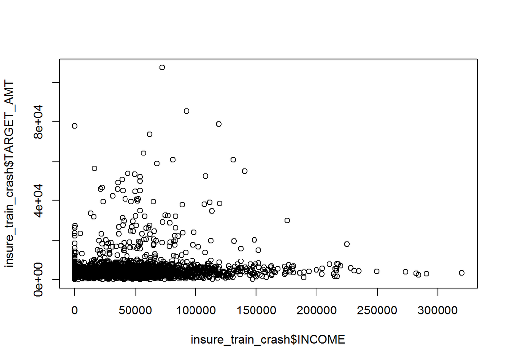

```r
check_bins <- function(var, thresholds) {
    col_x <- which(colnames(insure_train_crash)==var)
    old_x <- select(insure_train_crash, col_x)
    cor_old <- cor(old_x, insure_train_crash$TARGET_AMT,use = 'na.or.complete')
    ds <- data.frame("Item" = "Original", "Correlation"= round(cor_old, 5))

    old_tresh <- 0
    for(i in 1:length(thresholds)) {
        New_x <- ifelse((select(insure_train_crash, col_x) >= old_tresh & select(insure_train_crash, col_x)<=thresholds[i]),0,1)

        cor_new <- cor(New_x, insure_train_crash$TARGET_AMT,use = 'na.or.complete')

        ds_1 <- data.frame("Item" = as.character(thresholds[i]), "Correlation"= round(cor_new, 5))

        ds <- rbind(ds, ds_1)
        old_tresh <- thresholds[i]
    }

    return (ds)
}

plot(insure_train_crash$INCOME, insure_train_crash$TARGET_AMT)
```

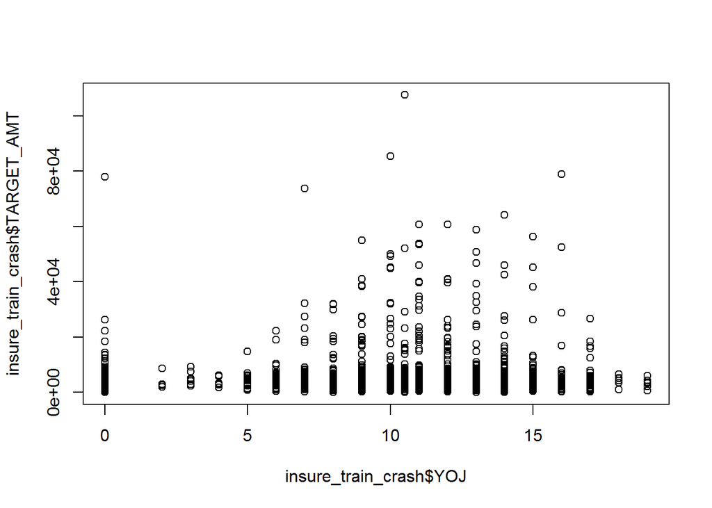

```r
#check_bins("INCOME", c(0, 50000, 125000, 200000))

plot(insure_train_crash$YOJ, insure_train_crash$TARGET_AMT)
```